# FE8828 Assignment for Exploratory Data Analysis

Yuxuan <sub><Email:yuan0080@e.ntu.edu.sg></sub>

Oct 2019

# Finding #1: Data Size

The bank dataset contains 4521 objects with 17 vairables.

# Finding #2: Data Summary

Based on the summary information, we can get the general profile of the bank clients. For example:

- Average and median age of the client is around 40 years old. Majority of the clients are in the range of 30 to 50 years old.
- The number of married clients is more than double of that of single clients.
- More than half of the clients own houses but less than 16% of the clients have loan.
- Majority of the clients obtain secondary or tertiary degree.
- Majority of the clients have not subscribed a term deposit.
- …

```r
kable(summary(bank)) %>% kable_styling(bootstrap_options = "striped", full_width = F)
```

|  | age | job | marital | education | default | balance | housing | loan | contact | day | month | duration | campaign | pdays | previous | poutcome | y |
| --- | --- | --- | --- | --- | --- | --- | --- | --- | --- | --- | --- | --- | --- | --- | --- | --- | --- |
|  | Min. :19.00 | management :969 | divorced: 528 | primary : 678 | no :4445 | Min. :-3313 | no :1962 | no :3830 | cellular :2896 | Min. : 1.00 | may :1398 | Min. : 4 | Min. : 1.000 | Min. : -1.00 | Min. : 0.0000 | failure: 490 | no :4000 |
|  | 1st Qu.:33.00 | blue-collar:946 | married :2797 | secondary:2306 | yes: 76 | 1st Qu.: 69 | yes:2559 | yes: 691 | telephone: 301 | 1st Qu.: 9.00 | jul : 706 | 1st Qu.: 104 | 1st Qu.: 1.000 | 1st Qu.: -1.00 | 1st Qu.: 0.0000 | other : 197 | yes: 521 |
|  | Median :39.00 | technician :768 | single :1196 | tertiary :1350 | NA | Median : 444 | NA | NA | unknown :1324 | Median :16.00 | aug : 633 | Median : 185 | Median : 2.000 | Median : -1.00 | Median : 0.0000 | success: 129 | NA |
|  | Mean :41.17 | admin. :478 | NA | unknown : 187 | NA | Mean : 1423 | NA | NA | NA | Mean :15.92 | jun : 531 | Mean : 264 | Mean : 2.794 | Mean : 39.77 | Mean : 0.5426 | unknown:3705 | NA |
|  | 3rd Qu.:49.00 | services :417 | NA | NA | NA | 3rd Qu.: 1480 | NA | NA | NA | 3rd Qu.:21.00 | nov : 389 | 3rd Qu.: 329 | 3rd Qu.: 3.000 | 3rd Qu.: -1.00 | 3rd Qu.: 0.0000 | NA | NA |
|  | Max. :87.00 | retired :230 | NA | NA | NA | Max. :71188 | NA | NA | NA | Max. :31.00 | apr : 293 | Max. :3025 | Max. :50.000 | Max. :871.00 | Max. :25.0000 | NA | NA |
|  | NA | (Other) :713 | NA | NA | NA | NA | NA | NA | NA | NA | (Other): 571 | NA | NA | NA | NA | NA | NA |

# Finding #3 Previous outcome vs days and number of contacts

pdays is defined as “number of days that passed by after the client was last contacted from a previous campaign (numeric, -1 means client was not previously contacted)” previous is defined as “number of contacts performed before this campaign and for this client”

Disregarding the “unknown case” where client was not previously contacted (pday is around -1 and previous is 0), success cases have the average pday of 163.7132, which is much lower than 243.1673 of failure cases and 219.3858 of other cases. This fact indicates that the more frequently client was contacted, the more likely the campaign would be success on the corresponding client.

In the case of average previous, other cases has the max value of 3.38787, followed by sucusses cases of 3.015504. Failure cases have the smallest average previous of 2.851020. This fact indicates that even though more contacts performed might not directly lead to campaign success, but would reduce the chance of failure cases.

```r
kable(group_by(bank, poutcome) %>% summarise(avgPday = mean(pdays), avgPrevious = mean(previous))) %>% kable_styling(bootstrap_options = "striped", full_width = F)
```

| poutcome | avgPday | avgPrevious |
| --- | --- | --- |
| failure | 243.1673 | 2.851020 |
| other | 219.3858 | 3.385787 |
| success | 163.7132 | 3.015504 |
| unknown | -1.0000 | 0.000000 |

# Finding #4 Age vs Default Percentage

The graph below shows the default rate for each age.

- Default happens mainly between age 22 and 57 (let’s call it “default age range”).
- Among the “default age range” as mentioned above, the default_percentage goes very random. Thus, we can say the probability of default seems uncorrelated with age.
- Considering the result in Finding 4, the density/number of client outside the “default age range” is very small. The general default rate is a very small number as well. The corresponidng default rate calculated might not be accurate.

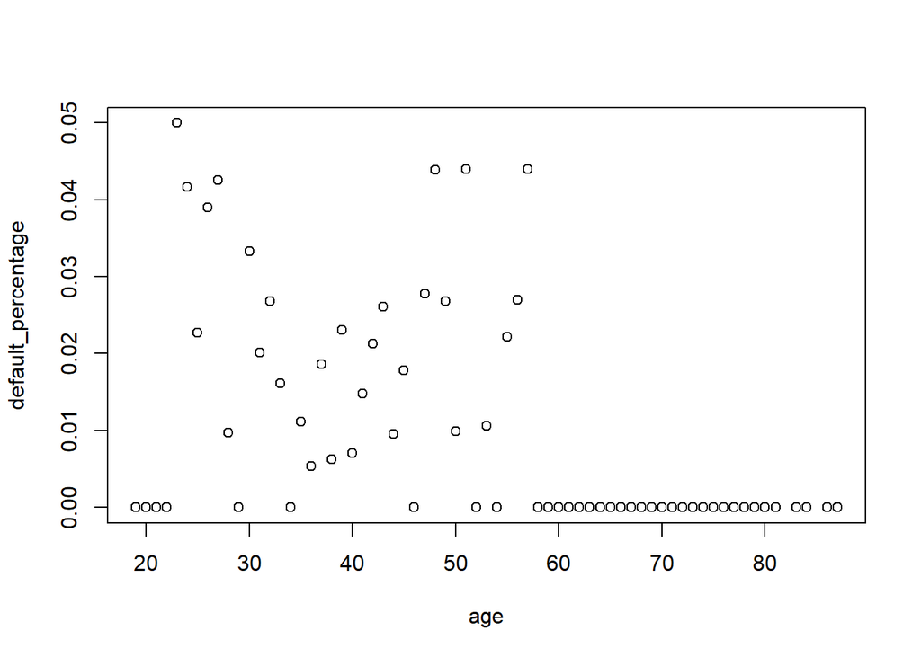

```r
bank_age <- group_by(bank, age) %>%
  summarise(
  default_percentage = sum(ifelse(default == "no", 0, 1))/n())

plot(bank_age)
```

# Finding #5 Cdays (number of days that passed by after the client was last contacted) statistics

In this quesion, I added a new varibale - cdays, whcih is defined as “the number of days that passed by after the client was last contacted.” Assuming that client was contacted at least once a year, i.e. I assume the year of last contact is the latest year from today.

```r
getLastDate <- function(d, m, currentDate){
  dateStr = paste0(d, "-", m, "-", year(currentDate))
  lastDate = as.Date(dateStr, "%d-%b-%Y")
  daysDiff = currentDate-lastDate
  diff = ifelse(lastDate < currentDate, 0, 1)
  return(lastDate - years(1*diff))
}

# To have the finding description static, I set the currentDate as "2019-10-06" here.
# In ideal case, currentDate should be Sys.date()
currentDate <- Sys.Date()
bank <- mutate(bank, cdate = getLastDate(day, month, currentDate))
bank <- mutate(bank, cdays = currentDate-cdate)

kable(summarise(
  bank,
  mean = mean(cdays),
  median = median(cdays),
  sd = sd(cdays),
  var = var(cdays),
  min = min(cdays),
  max = max(cdays)
)) %>% kable_styling(bootstrap_options = "striped", full_width = F)
```

| mean | median | sd | var | min | max |
| --- | --- | --- | --- | --- | --- |
| 160.7558 days | 155 days | 80.0383 | 6406.129 | 2 days | 364 days |

Based on the summary above, we know that:

- The cdays mean and median are 160.7558062 and 155 correspondingly. Thus, the distribution of cdays are generally positive skew with long right tail.
- The cdays min and max are 2 and 364 correspondingly. The min value indicates that the bank stuff has not contacted any client within recent 2 days.
- The variance and standard deviation are 6406.1292943 and 80.0382989 correspondingly. Thus the coefficient of variation is 0.4978875. Since coefficient is smaller than 1, the cdays distribution has a relatively low variation.

Following is the density plot of cdays. We can see it is not normally distributed, but a waved shape.

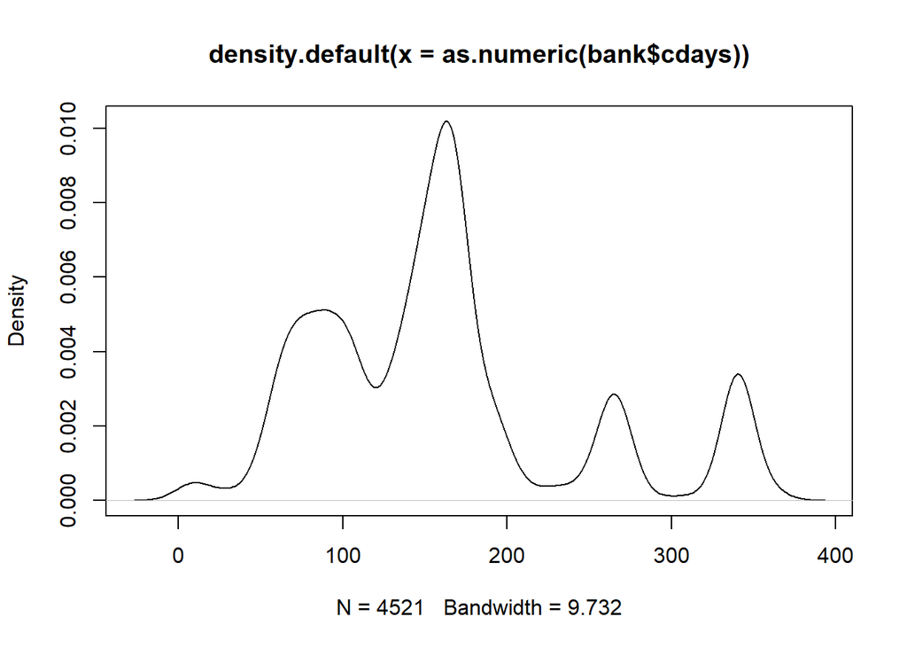

```r
plot(density(as.numeric(bank$cdays)))
```

# Finding #6 Age Group vs. poutcome

In generally, majority (81.950896%) of the previous marketing campaign result is unknown, followed by failure (10.838310%) and other status(4.357443%). Success is a reletivly rare event, with only 2.853351% of the population

```r
kable(group_by(bank, poutcome) %>% summarise(nPoutcome = n(), percentage = n()/nrow(bank))) %>% kable_styling(bootstrap_options = "striped", full_width = F)
```

| poutcome | nPoutcome | percentage |
| --- | --- | --- |
| failure | 490 | 0.1083831 |
| other | 197 | 0.0435744 |
| success | 129 | 0.0285335 |
| unknown | 3705 | 0.8195090 |

Next, I divide the client information into 3 age groups: “young” if age is smaller or equals to 30; “middle aged” if age is between 30 and 60 (right side inclusive); “senior” if age is larger than 60.

```r
bank <- mutate(bank, ageGroup = case_when(age<=30 ~ "young",
                                          (30 < age & age <= 60) ~"middle aged",
                                          60 <age ~ "senior"))

sum_ageGroup <- group_by(bank, ageGroup) %>% summarise(nAge = n())
kable(sum_ageGroup) %>% kable_styling(bootstrap_options = "striped", full_width = F)
```

| ageGroup | nAge |
| --- | --- |
| middle aged | 3762 |
| senior | 127 |
| young | 632 |

Based on the age group table above, we know that we have 3762 middle aged clients, 632 young clients and 127 senior clients.

Next, I am trying to analyse the relationship between age group and poutcome. Based on the summary table below, we can see that the success rate among senior client is obviously higher than young and middle-aged clients. Thus the marketing department should pay more efforts to senior clients because they are more possible to accept the marketing campaign.

```r
sum_ageGroup_poutcome <- group_by(bank, ageGroup,  poutcome) %>% summarise(n = n())
sum_ageGroup_poutcome <- right_join(sum_ageGroup_poutcome, sum_ageGroup, by = "ageGroup")
sum_ageGroup_poutcome <- mutate(sum_ageGroup_poutcome, percentage = n/nAge)
sum_ageGroup_poutcome <- select(sum_ageGroup_poutcome, ageGroup, poutcome, percentage)
kable(spread(sum_ageGroup_poutcome, ageGroup, percentage)) %>% kable_styling(bootstrap_options = "striped", full_width = F)
```

| poutcome | middle aged | senior | young |
| --- | --- | --- | --- |
| failure | 0.1095162 | 0.1811024 | 0.0870253 |
| other | 0.0417331 | 0.0314961 | 0.0569620 |
| success | 0.0252525 | 0.1338583 | 0.0268987 |
| unknown | 0.8234981 | 0.6535433 | 0.8291139 |

# Finding #7 Term deposit vs. client loyalty

Generally, clients who subscribed a term deposit is more loyal than those without term deposit subscription. Which means:

- Term deposit subscribers generally save more money into the bank –> Average balance of term deposit subscribers is 1571.956, while that of non-subscribers is only 1403.212.
- Term deposit subscribers are willing to spend more time contacting bank staff –> Mean duration is 552.7428 second for term deposit subscribers, which is around double of that of non-subscribers.

However, only 11.524% clients have subscribed a term deposit. The bank should promote its term deposit subscription more.

```r
if("y" %in% colnames(bank))
{
  bank <- rename(bank, `term deposit subscription` = y)
}
kable(group_by(bank, `term deposit subscription`) %>% summarise(count = n(), percentage = n()/nrow(bank), mean(balance), mean(age), mean(duration))) %>% kable_styling(bootstrap_options = "striped", full_width = F)
```

| term deposit subscription | count | percentage | mean(balance) | mean(age) | mean(duration) |
| --- | --- | --- | --- | --- | --- |
| no | 4000 | 0.88476 | 1403.212 | 40.99800 | 226.3475 |
| yes | 521 | 0.11524 | 1571.956 | 42.49136 | 552.7428 |

# Finding #8 Loan

Most clients(47.62221%) take housing loan only, followed by clients with no loan product with 37.09356%. 8.98031% clients have both housing loan and personal loan, and 6.30392% clients take personal loan only. Thus, housing loan is much more popular than personal loan, which might be the strength of the bank. The bank should pay more effor to promote its personal loan becuase it has more space to growth.

```r
bank <- mutate(bank, `loan status` = ifelse(housing == "yes", ifelse(loan == "yes", "both", "housing only"), ifelse(loan == "yes", "personal only", "none")))
kable(group_by(bank, `loan status`) %>% summarise(count = n(), percentage = n()/nrow(bank))) %>% kable_styling(bootstrap_options = "striped", full_width = F)
```

| loan status | count | percentage |
| --- | --- | --- |
| both | 406 | 0.0898031 |
| housing only | 2153 | 0.4762221 |
| none | 1677 | 0.3709356 |
| personal only | 285 | 0.0630392 |

# Finding #9 Defualt Rate

Even though default is a rare event, bank should know what kind of clients has higher default rate for better risk control.

### Defualt Rate vs. Job

Entrepreneur has sigificantly higher default rate, 4.16667%, than any other jobs. The bank should pay more attention on the risk control on entrepreneur clients.

Besides entrepreneur, unemployed and self-employed’s default rate are larger than 2% as well.

```r
bank_job <- group_by(bank, job) %>%
  summarise(
  default_percentage = sum(ifelse(default == "no", 0, 1))/n())
kable(bank_job) %>% kable_styling(bootstrap_options = "striped", full_width = F)
```

| job | default_percentage |
| --- | --- |
| admin. | 0.0125523 |
| blue-collar | 0.0147992 |
| entrepreneur | 0.0416667 |
| housemaid | 0.0178571 |
| management | 0.0144479 |
| retired | 0.0130435 |
| self-employed | 0.0218579 |
| services | 0.0167866 |
| student | 0.0119048 |
| technician | 0.0195312 |
| unemployed | 0.0234375 |
| unknown | 0.0000000 |

### Defualt Rate vs. Education

Even though clients with secondary education have higher defalt percentage, the difference among different education groups is not that huge. Thus, the eudcation level is generally not a indicator of default.

```r
bank_education <- group_by(bank, education) %>%
  summarise(
  default_percentage = sum(ifelse(default == "no", 0, 1))/n())
kable(bank_education) %>% kable_styling(bootstrap_options = "striped", full_width = F)
```

| education | default_percentage |
| --- | --- |
| primary | 0.0147493 |
| secondary | 0.0199480 |
| tertiary | 0.0125926 |
| unknown | 0.0160428 |

### Defualt Rate vs. Marital

Divorced clients has sgnificant higher default percentage than other clients. The bank should pay more attention to their risk control. Married people have the most stable financial status.

```r
bank_marital <- group_by(bank, marital) %>%
  summarise(
  default_percentage = sum(ifelse(default == "no", 0, 1))/n())
kable(bank_marital) %>% kable_styling(bootstrap_options = "striped", full_width = F)
```

| marital | default_percentage |
| --- | --- |
| divorced | 0.0340909 |
| married | 0.0128709 |
| single | 0.0183946 |

# Finding #10 Marital vs. Loan

Married clients generally has higher demand on housing loan, than other marital groups. Divorced clients generally has higher personal loan demand than other two marital groups.

However the difference is not that significant, thus marital status and loan choice are not so close correlated.

```r
bank_marital_housing_loan <- group_by(bank, marital) %>%
  summarise(
  housing_loan_percentage = sum(ifelse(housing == "no", 0, 1))/n(),
  personal_loan_percentage = sum(ifelse(loan == "no", 0, 1))/n())
kable(bank_marital_housing_loan) %>% kable_styling(bootstrap_options = "striped", full_width = F)
```

| marital | housing_loan_percentage | personal_loan_percentage |
| --- | --- | --- |
| divorced | 0.5643939 | 0.1704545 |
| married | 0.5809796 | 0.1619592 |
| single | 0.5317726 | 0.1237458 |